# Income and Inflation Trends in Michigan Counties

Author

Elle Miller

Published

December 5, 2025

# Data Dictionary

**Census Data (Michigan Counties 2009-2023):**

- `geoid` (character): Geographic region ID - first 2 digits are state FIPS code, last 3 digits are county FIPS code
- `county_state` (character): County name and state
- `year` (numeric): Year of data collection
- `population` (numeric): Total population count
- `median_income` (numeric): Median household income in dollars
- `median_monthly_rent_cost` (numeric): Median monthly rent for renters in dollars
- `median_monthly_home_cost` (numeric): Median monthly housing costs for homeowners in dollars
- `prop_female` (numeric): Proportion of population that is female (0-1 scale)
- `prop_poverty` (numeric): Proportion of population 25+ living below poverty threshold (0-1 scale)

**CPI Data (2000-2024):**

- `year` (numeric): Year of observation
- `period` (character): Period code (e.g., M12 for December)
- `period_name` (character): Month name
- `series_id` (character): Series identifier
- `date` (date): Full date of observation
- `cpi` (numeric): Consumer Price Index value (measures inflation)

# Data Cleaning

```r
# Load libraries
library(tidyverse)
library(lubridate)
library(flextable)
library(naniar)
library(skimr)
```

```r
# Load census data
census <- read_csv("https://raw.githubusercontent.com/dilernia/STA418-518/main/Data/census_data_county_2009-2023.csv")

# Load CPI data
cpi <- read_csv("https://raw.githubusercontent.com/dilernia/STA418-518/refs/heads/main/Data/cpi_2000-2024.csv")

# Filter to Michigan counties
michigan_census <- census |>
  filter(geoid >= 26000 & geoid < 27000) |>
  mutate(geoid = as.character(geoid))
```

## Merging data sets

```r
# Get annual average CPI for each year
cpi_annual <- cpi |>
  group_by(year) |>
  summarize(avg_cpi = mean(cpi, na.rm = TRUE))

# Join census data with CPI data
michigan_with_cpi <- michigan_census |>
  left_join(cpi_annual, by = "year")
```

## String manipulation

```r
michigan_with_cpi <- michigan_with_cpi |>
  mutate(
    # Extract county name without state
    county_name = str_remove(county_state, ", Michigan"),

    # Convert to title case
    county_clean = str_to_title(county_name),

    # Remove County if present
    county_short = str_remove(county_clean, " County$"),

    # Create geographic regions based on county names
    region = case_when(
      str_detect(county_short, "^(Wayne|Oakland|Macomb)$") ~ "Metro Detroit",
      str_detect(county_short, "^(Kent|Ottawa|Allegan|Barry)$") ~ "West Michigan",
      str_detect(county_short, "^(Washtenaw|Livingston|Lenawee|Monroe)$") ~ "Southeast Michigan",
      str_detect(county_short, "^(Ingham|Eaton|Clinton)$") ~ "Mid Michigan",
      str_detect(county_short, "^(Marquette|Houghton|Keweenaw|Ontonagon|Gogebic|Iron|Baraga|Dickinson|Menominee|Delta|Alger|Schoolcraft|Luce|Chippewa|Mackinac)$") ~ "Upper Peninsula",
      TRUE ~ "Northern & Rural Michigan"
    )
  )
```

## Date time functions

```r
michigan_with_cpi <- michigan_with_cpi |>
  mutate(
    # Create date from year (1,1 for January 1st start)
    date_reference = make_date(year, 1, 1),

    # Calculate years since start of dataset
    years_since_start = interval(make_date(2009, 1, 1), date_reference) / years(1),

    # Identify pre-pandemic vs post-pandemic periods
    pandemic_period = case_when(
      year < 2020 ~ "Pre-Pandemic (2009-2019)",
      year == 2020 ~ "Pandemic Year (2020)",
      TRUE ~ "Post-Pandemic (2021-2023)"
    )
  )
```

# Exploratory Data Analysis

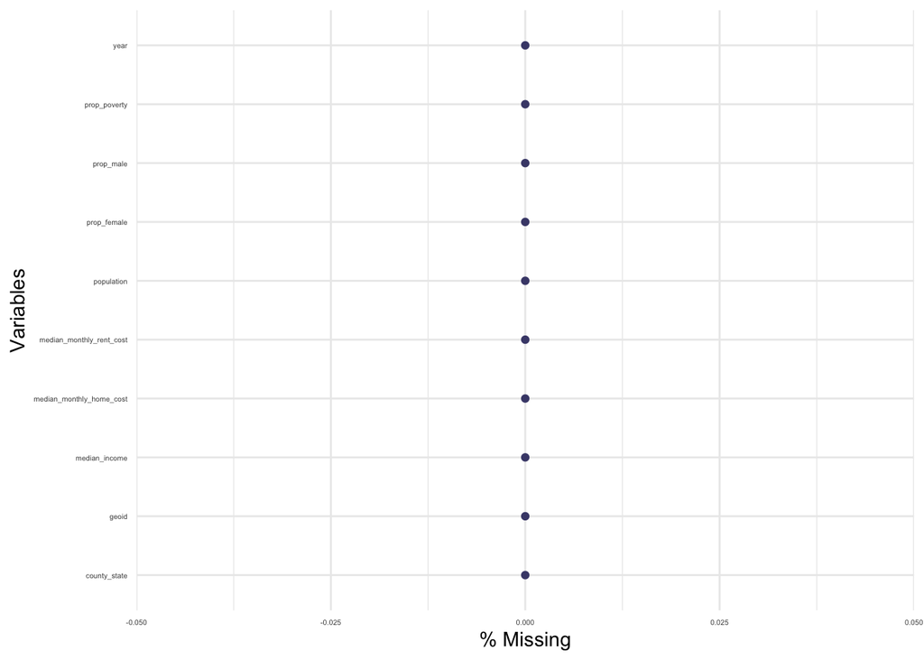

```r
# Michigan Census data missingness
gg_miss_var(michigan_census, show_pct = TRUE) +
  theme(axis.text = element_text(size = 4))
```

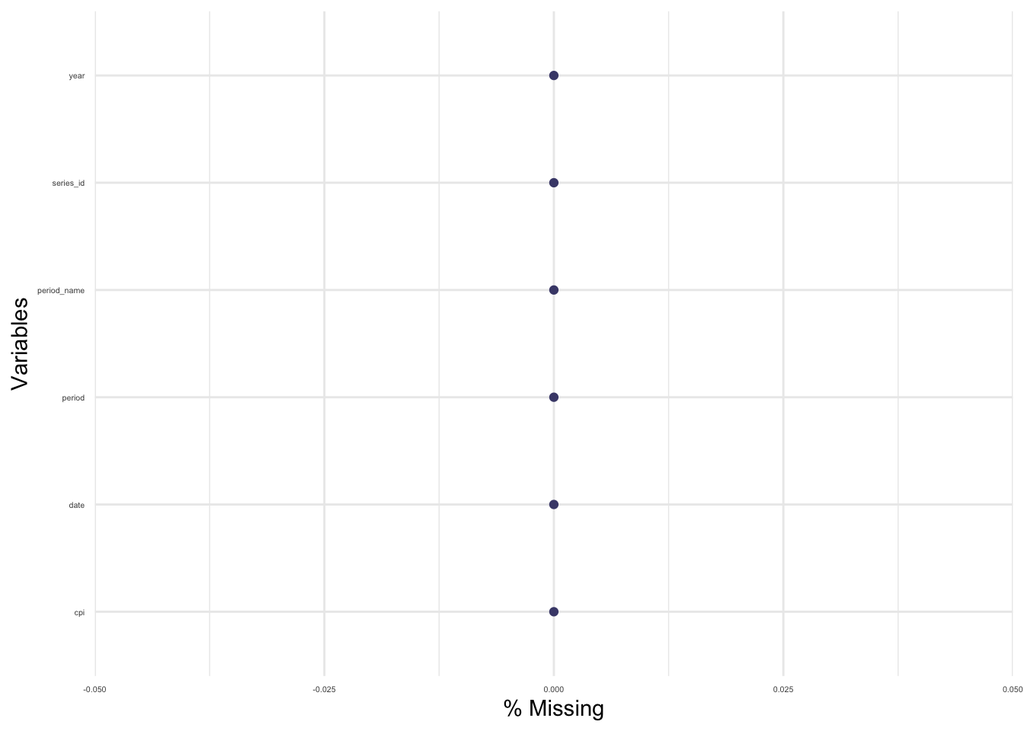

```r
# CPI data missingness
gg_miss_var(cpi, show_pct = TRUE) +
  theme(axis.text = element_text(size = 4))
```

**Missingness Analysis:** The dataset has seemingly no missing values. However, the year 2020 is completely absent because the Census Bureau did not collect this data during this time period. Yet, missing values are minimal and won’t affect the analysis.

## Tables of summary statistics

```r
# Summary statistics by region
regional_summary <- michigan_with_cpi |>
  group_by(region) |>
  summarize(
    avg_income = round(mean(median_income, na.rm = TRUE), digits = 2),
    avg_poverty_pct = round(mean(prop_poverty * 100, na.rm = TRUE), digits = 2),
    avg_population = round(mean(population, na.rm = TRUE), digits = 2)
  ) |>
  arrange(desc(avg_income))

  regional_summary |>
    flextable() |>
    set_header_labels(region = "Region",
    avg_income = "Median Income ($)",
    avg_poverty_pct = "Poverty Rate (%)",
    avg_population = "Average Population") |>
    theme_zebra()
```

| Region | Median Income ($) | Poverty Rate (%) | Average Population |
| --- | --- | --- | --- |
| Southeast Michigan | 65,052.80 | 11.01 | 198,672.96 |
| West Michigan | 60,504.21 | 10.87 | 269,699.09 |
| Metro Detroit | 59,838.17 | 14.25 | 1,298,891.74 |
| Mid Michigan | 59,124.45 | 13.23 | 156,206.43 |
| Northern & Rural Michigan | 47,143.33 | 15.95 | 63,188.27 |
| Upper Peninsula | 43,330.06 | 15.55 | 20,486.32 |

**Regional Statistics Analysis:** Income levels vary substantially across Michigan’s regions. Southeast and West Michigan consistently report the highest median incomes. Poverty rates are generally lowest in these same regions, while Northern & Rural areas and the Upper Peninsula show lower incomes and higher poverty.

```r
# Get values for specific years
year_2009 <- michigan_with_cpi |>
  filter(year == 2009) |>
  summarize(
    avg_income = round(mean(median_income, na.rm = TRUE), digits = 2),
    avg_cpi = round(mean(avg_cpi, na.rm = TRUE), digits = 2),
    avg_poverty = round(mean(prop_poverty * 100, na.rm = TRUE), digits = 2)
  )

year_2015 <- michigan_with_cpi |>
  filter(year == 2015) |>
  summarize(
    avg_income = round(mean(median_income, na.rm = TRUE), digits = 2),
    avg_cpi = round(mean(avg_cpi, na.rm = TRUE), digits = 2),
    avg_poverty = round(mean(prop_poverty * 100, na.rm = TRUE), digits = 2)
  )

year_2023 <- michigan_with_cpi |>
  filter(year == 2023) |>
  summarize(
    avg_income = round(mean(median_income, na.rm = TRUE), digits = 2),
    avg_cpi = round(mean(avg_cpi, na.rm = TRUE), digits = 2),
    avg_poverty = round(mean(prop_poverty * 100, na.rm = TRUE), digits = 2)
  )

# Calculate changes
growth_comparison <- tibble(
  year = c(2015, 2023),
  avg_income = c(year_2015$avg_income, year_2023$avg_income),
  avg_cpi = c(year_2015$avg_cpi, year_2023$avg_cpi),
  avg_poverty = c(year_2015$avg_poverty, year_2023$avg_poverty),
  income_change = round(c(
    ((year_2015$avg_income / year_2009$avg_income) - 1) * 100,
    ((year_2023$avg_income / year_2015$avg_income) - 1) * 100
  ), digits = 2),
  inflation = round(c(
    ((year_2015$avg_cpi / year_2009$avg_cpi) - 1) * 100,
    ((year_2023$avg_cpi / year_2015$avg_cpi) - 1) * 100
  ), digits = 2)
)

growth_comparison |>
  flextable() |>
  set_header_labels(
    year = "Year",
    avg_income = "Avg Income ($)",
    avg_cpi = "CPI",
    avg_poverty = "Poverty Rate (%)",
    income_change = "Income Growth (%)",
    inflation = "Inflation (%)"
  ) |>
  theme_zebra()
```

| Year | Avg Income ($) | CPI | Poverty Rate (%) | Income Growth (%) | Inflation (%) |
| --- | --- | --- | --- | --- | --- |
| 2,015 | 44,464.99 | 237.02 | 16.69 | 2.47 | 10.48 |
| 2,023 | 64,303.95 | 304.70 | 13.21 | 44.62 | 28.55 |

```r
# Compare before COVID (2009-2019) to after COVID (2021-2023)

# Calculate averages for before COVID
before_covid <- michigan_with_cpi |>
  filter(year < 2020) |>
  group_by(region) |>
  summarize(
    income_before = round(mean(median_income, na.rm = TRUE), digits = 2),
    poverty_before = round(mean(prop_poverty * 100, na.rm = TRUE), digits = 2)
  )

# Calculate averages for after COVID
after_covid <- michigan_with_cpi |>
  filter(year > 2020) |>
  group_by(region) |>
  summarize(
    income_after = round(mean(median_income, na.rm = TRUE), digits = 2),
    poverty_after = round(mean(prop_poverty * 100, na.rm = TRUE), digits = 2)
  )

# Join the two tables and calculate changes
pandemic_comparison <- before_covid |>
  left_join(after_covid, by = "region") |>
  mutate(
    income_change = round(((income_after / income_before) - 1) * 100, digits = 2),
    poverty_change = round((poverty_after - poverty_before), digits = 2)
  ) |>
  arrange(desc(income_change))

# Display table
pandemic_comparison |>
  flextable() |>
  set_header_labels(
    region = "Region",
    income_before = "Income Before COVID ($)",
    income_after = "Income After COVID ($)",
    income_change = "Income Change (%)",
    poverty_before = "Poverty Before COVID (%)",
    poverty_after = "Poverty After COVID (%)",
    poverty_change = "Poverty Change"
  ) |>
  theme_vanilla()
```

| Region | Income Before COVID ($) | Poverty Before COVID (%) | Income After COVID ($) | Poverty After COVID (%) | Income Change (%) | Poverty Change |
| --- | --- | --- | --- | --- | --- | --- |
| West Michigan | 56,035.18 | 11.38 | 76,890.67 | 8.99 | 37.22 | -2.39 |
| Northern & Rural Michigan | 43,905.35 | 16.54 | 59,015.90 | 13.77 | 34.42 | -2.77 |
| Upper Peninsula | 40,454.63 | 16.05 | 53,873.31 | 13.73 | 33.17 | -2.32 |
| Mid Michigan | 55,335.15 | 13.79 | 73,018.56 | 11.21 | 31.96 | -2.58 |
| Metro Detroit | 56,101.06 | 14.69 | 73,540.89 | 12.63 | 31.09 | -2.06 |
| Southeast Michigan | 61,295.36 | 11.22 | 78,830.08 | 10.24 | 28.61 | -0.98 |

**Pre-Pandemic vs Post-Pandemic Analysis: Median income is noticeably higher and poverty rates declines in the post pandemic years compared to the pre pandemic period. This indicates that many households have experienced improvement in financial stability since 2020.**

## Data visualizations

### Average Median Income Trends

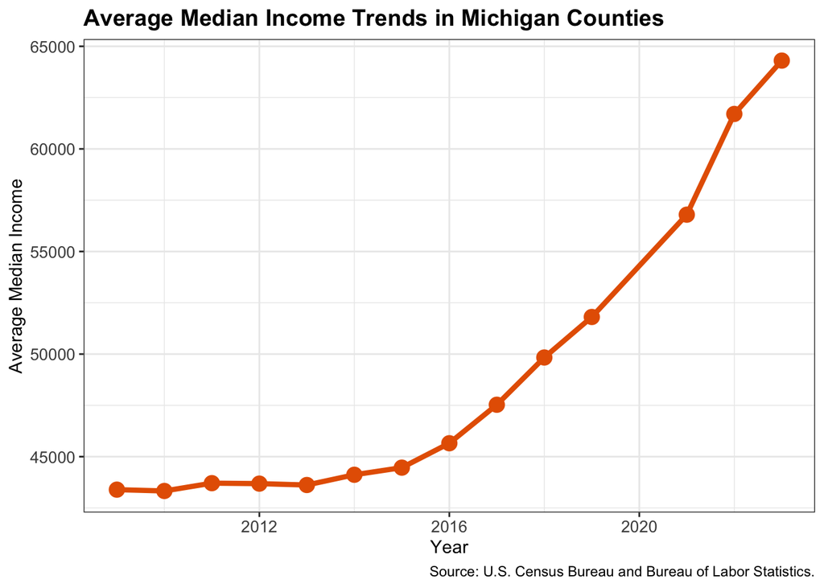

```r
michigan_with_cpi |>
  group_by(year) |>
  summarize(avg_median_income = mean(median_income, na.rm = TRUE)) |>
  ggplot(aes(x = year, y = avg_median_income)) +
  geom_line(color = "#E66100", linewidth = 1.5) +
  geom_point(color = "#E66100", size = 4) +
  labs(
    title = "Average Median Income Trends in Michigan Counties",
    x = "Year",
    y = "Average Median Income",
    caption = "Source: U.S. Census Bureau and Bureau of Labor Statistics."
  ) +
  theme_bw() +
  theme(
    plot.title = element_text(face = "bold", size = 14),
    axis.text = element_text(size = 10)
  )
```

### Top 10 Counties by Income

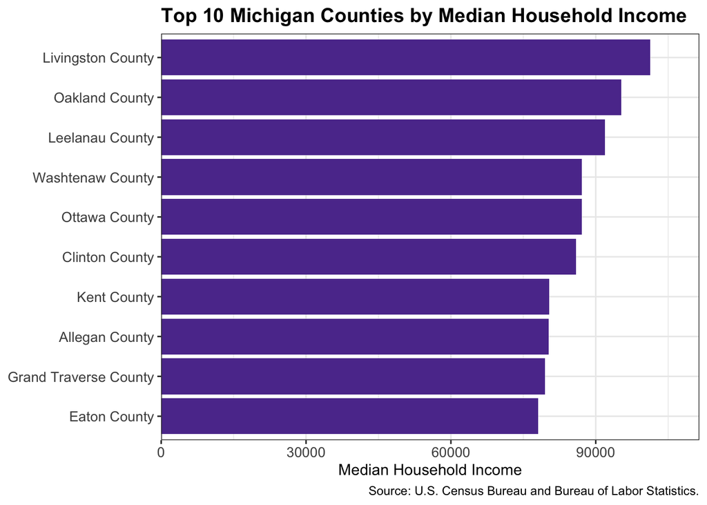

```r
# Bar chart of top counties by income
michigan_with_cpi |>
  filter(year == 2023) |>
  arrange(desc(median_income)) |>
  slice_head(n = 10) |>
  ggplot(aes(x = reorder(county_clean, median_income), y = median_income)) +
  geom_col(fill = "#5D3A9B") +
  coord_flip() +
  scale_y_continuous(expand = expansion(mult = c(0, 0.1))) +
  labs(
    title = "Top 10 Michigan Counties by Median Household Income",
    x = NULL,
    y = "Median Household Income",
    caption = "Source: U.S. Census Bureau and Bureau of Labor Statistics."
  ) +
  theme_bw() +
  theme(
    plot.title = element_text(face = "bold", size = 14),
    axis.text = element_text(size = 10)
  )
```

**Top 10 Incomes Analysis:** Counties with the highest median incomes show a consistent pattern of stronger economies and higher wage levels. These counties tend to be suburban or urban areas with higher populations.

### Income vs Poverty

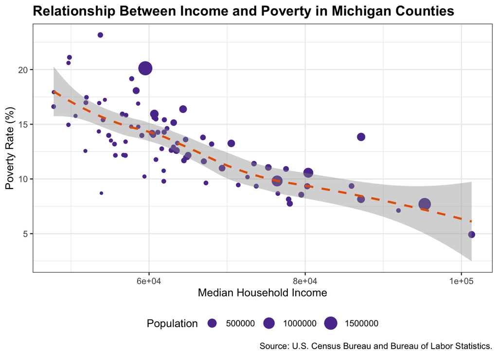

```r
# Scatter plot of income vs poverty
michigan_with_cpi |>
  filter(year == 2023) |>
  ggplot(aes(x = median_income, y = prop_poverty * 100)) +
  geom_point(aes(size = population), color = "#5D3A9B") +
  geom_smooth(color = "#E66100", linetype = "dashed") +
  labs(
    title = "Relationship Between Income and Poverty in Michigan Counties",
    x = "Median Household Income",
    y = "Poverty Rate (%)",
    size = "Population",
    caption = "Source: U.S. Census Bureau and Bureau of Labor Statistics."
  ) +
  theme_bw() +
  theme(
    plot.title = element_text(face = "bold", size = 14),
    legend.position = "bottom"
  )
```

**Income vs Poverty Analysis:** The regression line slopes downward, showing a negative relationship between income and poverty. Counties with higher incomes generally have lower poverty rates, confirming income as a strong predictor of well being.

### Distribution of Rent Costs

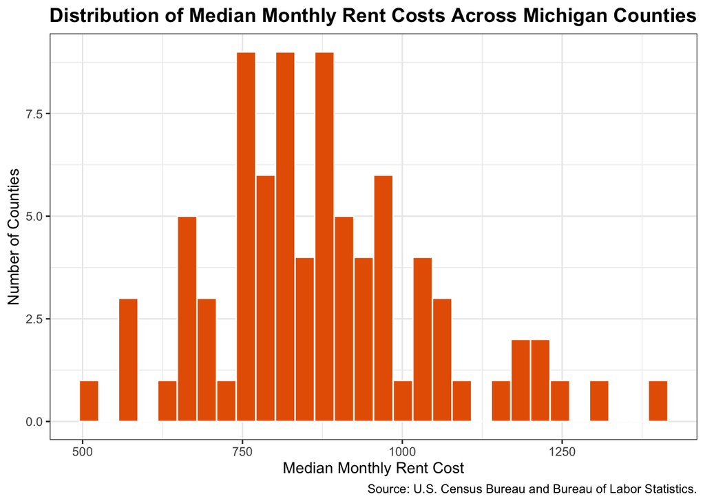

```r
# Histogram of rent costs
michigan_with_cpi |>
  filter(year == 2023) |>
  ggplot(aes(x = median_monthly_rent_cost)) +
  geom_histogram(fill = "#E66100", color = "white") +
  labs(
    title = "Distribution of Median Monthly Rent Costs Across Michigan Counties",
    x = "Median Monthly Rent Cost",
    y = "Number of Counties",
    caption = "Source: U.S. Census Bureau and Bureau of Labor Statistics."
  ) +
  theme_bw() +
  theme(
    plot.title = element_text(face = "bold", size = 14)
  )
```

**Rent Costs Analysis:** Rent prices in 2023 cluster around a central range, with a slightly right skewed distribution. This means a small number of counties have much higher housing costs and most counties have housing costs int the range of $750-$950.

### CPI Over Time

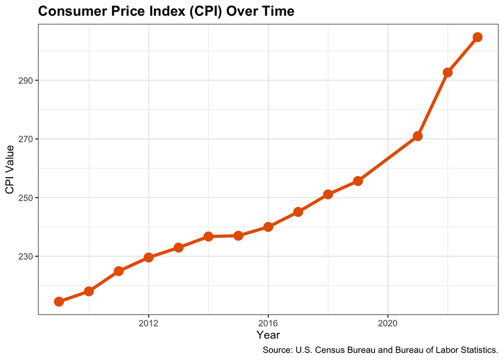

```r
# Show how inflation changed over time
michigan_with_cpi |>
  group_by(year) |>
  summarize(avg_cpi = mean(avg_cpi, na.rm = TRUE)) |>
  ggplot(aes(x = year, y = avg_cpi)) +
  geom_line(color = "#E66100", linewidth = 1.5) +
  geom_point(color = "#E66100", size = 4) +
  labs(
    title = "Consumer Price Index (CPI) Over Time",
    x = "Year",
    y = "CPI Value",
    caption = "Source: U.S. Census Bureau and Bureau of Labor Statistics."
  ) +
  theme_bw() +
  theme(
    plot.title = element_text(face = "bold", size = 14)
  )
```

**CPI Analysis:** CPI gradually rises across all years but spikes sharply after 2020. This shows that Michigan households faced significantly higher living costs in the post pandemic period.

### Income Growth vs Inflation by Year

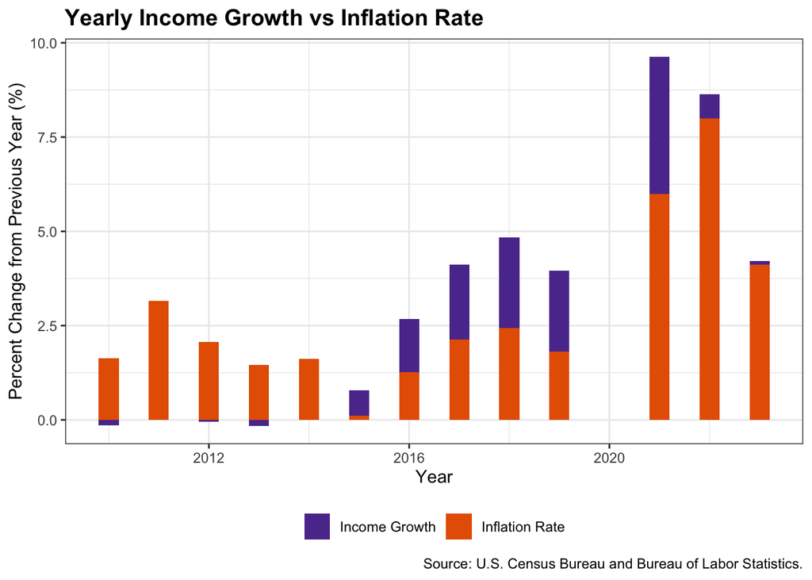

```r
# Calculate year-to-year changes
michigan_with_cpi |>
  group_by(year) |>
  summarize(
    avg_income = mean(median_income, na.rm = TRUE),
    avg_cpi = mean(avg_cpi, na.rm = TRUE)
  ) |>
  arrange(year) |>
  mutate(
    income_growth = ((avg_income / lag(avg_income)) - 1) * 100,
    inflation_rate = ((avg_cpi / lag(avg_cpi)) - 1) * 100
  ) |>
  filter(!is.na(income_growth)) |>
  ggplot(aes(x = year)) +
  geom_col(aes(y = income_growth, fill = "Income Growth"), width = 0.4) +
  geom_col(aes(y = inflation_rate, fill = "Inflation Rate"), width = 0.4) +
  scale_fill_manual(values = c("Income Growth" = "#5D3A9B",
                                "Inflation Rate" = "#E66100")) +
  labs(
    title = "Yearly Income Growth vs Inflation Rate",
    x = "Year",
    y = "Percent Change from Previous Year (%)",,
    caption = "Source: U.S. Census Bureau and Bureau of Labor Statistics.",
    fill = NULL
  ) +
  theme_bw() +
  theme(legend.position = "bottom", plot.title = element_text(face = "bold", size = 14))
```

# Permutation or Randomization Test

## Research Question

Did poverty rates significantly decrease from 2009 to 2023 in Michigan counties?

### Hypotheses

**Formal statement of hypotheses**

Hypotheses are given by:

$$H_0: \mu_{2009} = \mu_{2023}$$
$$H_1: \mu_{2009} > \mu_{2023}$$

where $\mu_{2009}$ is the average poverty rate in 2009 and $\mu_{2023}$ is the average poverty rate in 2023.

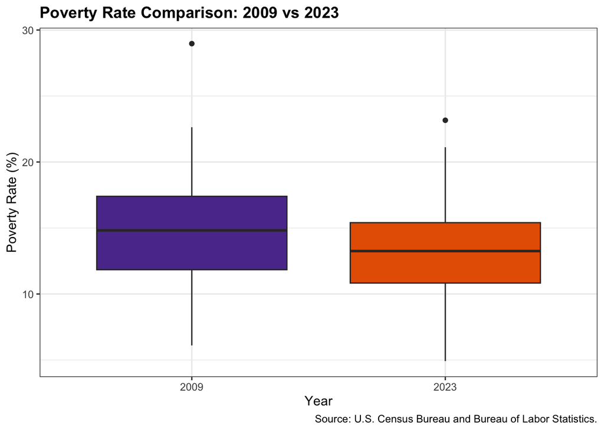

```r
# Get data for just 2009 and 2023
test_data <- michigan_with_cpi |>
  filter(year %in% c(2009, 2023)) |>
  mutate(year_group = as.character(year))

# Boxplot comparison
test_data |>
  ggplot(aes(x = year_group, y = prop_poverty * 100, fill = year_group)) +
  geom_boxplot() +
  scale_fill_manual(values = c("#5D3A9B", "#E66100")) +
  labs(
    title = "Poverty Rate Comparison: 2009 vs 2023",
    x = "Year",
    y = "Poverty Rate (%)",
    caption = "Source: U.S. Census Bureau and Bureau of Labor Statistics."
  ) +
  theme_bw() +
  theme(legend.position = "none", plot.title = element_text(face = "bold"))
```

```r
# Summary statistics
test_data |>
  group_by(year_group) |>
  summarize(
    n = n(),
    Mean = round(mean(prop_poverty * 100, na.rm = TRUE), digits = 2),
    SD = round(sd(prop_poverty * 100, na.rm = TRUE), digits = 2)
  ) |>
  flextable() |>
    set_header_labels(year_group = "Year",
    n = "Counties",
    Mean = "Mean",
    SD = "SD") |>
  theme_zebra()
```

| Year | Counties | Mean | SD |
| --- | --- | --- | --- |
| 2009 | 83 | 14.69 | 4.07 |
| 2023 | 83 | 13.21 | 3.43 |

### Running the Permutation Test

```r
# Calculate observed difference (2009 - 2023)
observed_diff <- test_data |>
  group_by(year_group) |>
  summarize(mean_poverty = mean(prop_poverty * 100, na.rm = TRUE)) |>
  summarize(diff = first(mean_poverty) - last(mean_poverty)) |>
  pull(diff)

# Run permutation test
n_permutations <- 10000
permutation_diffs <- vector(length = n_permutations)

for(i in 1:n_permutations) {
  permutation_diffs[i] <- test_data |>
    mutate(year_group = sample(year_group)) |>
    group_by(year_group) |>
    summarize(mean_poverty = mean(prop_poverty * 100, na.rm = TRUE)) |>
    summarize(diff = first(mean_poverty) - last(mean_poverty)) |>
    pull(diff)
}

# Calculate p-value (one-tailed test)
p_value <- mean(permutation_diffs >= observed_diff)
```

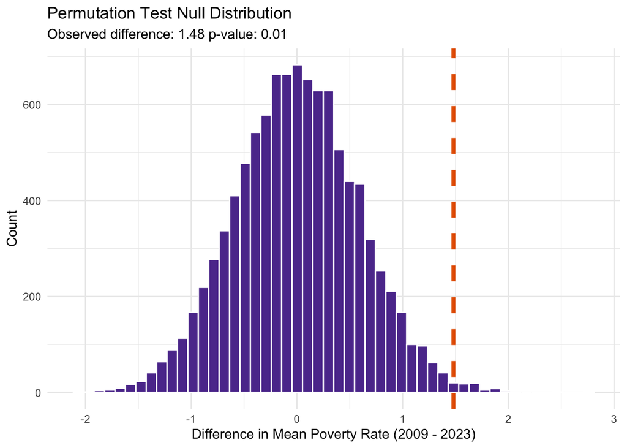

```r
# Permutation Test Results

# Plot null distribution
tibble(diff = permutation_diffs) |>
  ggplot(aes(x = diff)) +
  geom_histogram(bins = 50, fill = "#5D3A9B", color = "white") +
  geom_vline(xintercept = observed_diff, color = "#E66100",
             linewidth = 1.5, linetype = "dashed") +
  labs(
    title = "Permutation Test Null Distribution",
    subtitle = paste("Observed difference:", round(observed_diff, 2),
                        "p-value:", round(p_value, 2)),
    x = "Difference in Mean Poverty Rate (2009 - 2023)",
    y = "Count"
  ) +
  theme_minimal()
```

### Interpretation

**Decision:** We reject the null hypothesis.

**Interpretation:** Michigan counties experienced a statistically significant decrease in poverty rates from 2009 to 2023.

# Conclusions

This project looked at how income and poverty changed in Michigan counties from 2009 to 2023, and compared these changes to national inflation rates.

### Higher Income Counties Have Lower Poverty

Counties with higher median incomes have lower poverty rates. This was not surprising since, typically, when an area has well paying jobs, fewer people live in poverty. However, income isn’t the only factor. Some counties with similar incomes have different poverty rates, which means other things like cost of living and available services also matter.

### Housing Costs Are Still Affordable in Most Areas

Most Michigan counties have median rents between $700 and $900 per month, which is relatively affordable. However, the wealthiest counties (especially near Detroit and Ann Arbor) have rents over $1,000 per month. This can make it hard for people with lower incomes to afford housing in areas with the best job opportunities.

## What This Data Doesn’t Tell Us

My analysis has some limitations. The year 2020 is completely missing from the census data, so we can’t see exactly what happened during the worst part of the pandemic. I only examined income and rent costs, not other important expenses like healthcare, childcare, or food. Finally, my analysis looked at entire counties, which can hide differences between cities and rural areas within the same county.

## What Could Be Done

**Help struggling regions:** Northern Michigan and the Upper Peninsula need more economic development support since they have lower incomes and higher poverty than other parts of the state.

**Keep housing affordable:** In expensive areas like Southeast Michigan, it’s getting harder for people to afford rent. Building more housing could help keep costs reasonable.

**Watch out for inflation:** The last few years showed how rising prices can make people feel worse off even when their paychecks are larger. This is something to keep monitoring.

### References

https://davidgohel.github.io/flextable/reference/set_header_labels.html

https://stringr.tidyverse.org/reference/str_c.html

https://stringr.tidyverse.org/reference/case.html

https://posit.cloud/learn/recipes/datetime/DatetimeA3

https://github.com/rstudio/cheatsheets/blob/main/strings.pdf

https://www.rdocumentation.org/packages/base/versions/3.6.2/topics/character

https://stackoverflow.com/questions/50268390/regular-expression-in-str-detect

Copilot Editor (debug permutation test)